# Assignment 2

Fabrizio Fiorini

2/24/2021

## Module 4 - k-NN Classification Model

This assignment consists on applying a k-NN model on a dataset of 5,000 customers of the Universal Bank. The object is to predict whether a new customer would accept a personal loan offer.

```r
#install (if necessary) and load the required libraries
library(caret)
```

```r
library(FNN)
library(ggplot2)
library("gmodels")
library(ISLR)
library(dplyr)
library(fastDummies)
library(dummies)
```

# Import and Exploration of the dataset

We use the read.csv function to load the file that contains the dataframe of Universal Bank’s customers. Then, we will run some exploratory analisys to get familiar with the dataset.

```r
#Importing the database
customers <- read.csv("UniversalBank.csv")
```

```r
#Exploring the data by previewing the first 6 rows and all the 14 variables.
head(customers)
```

```
##   ID Age Experience Income ZIP.Code Family CCAvg Education Mortgage
## 1  1  25          1     49    91107      4   1.6         1        0
## 2  2  45         19     34    90089      3   1.5         1        0
## 3  3  39         15     11    94720      1   1.0         1        0
## 4  4  35          9    100    94112      1   2.7         2        0
## 5  5  35          8     45    91330      4   1.0         2        0
## 6  6  37         13     29    92121      4   0.4         2      155
##   Personal.Loan Securities.Account CD.Account Online CreditCard
## 1             0                  1          0      0          0
## 2             0                  1          0      0          0
## 3             0                  0          0      0          0
## 4             0                  0          0      0          0
## 5             0                  0          0      0          1
## 6             0                  0          0      1          0
```

```r
#Looking at the structure of the dataset.
str(customers)
```

```
## 'data.frame':    5000 obs. of  14 variables:
##  $ ID                : int  1 2 3 4 5 6 7 8 9 10 ...
##  $ Age               : int  25 45 39 35 35 37 53 50 35 34 ...
##  $ Experience        : int  1 19 15 9 8 13 27 24 10 9 ...
##  $ Income            : int  49 34 11 100 45 29 72 22 81 180 ...
##  $ ZIP.Code          : int  91107 90089 94720 94112 91330 92121 91711 93943 90089 93023 ...
##  $ Family            : int  4 3 1 1 4 4 2 1 3 1 ...
##  $ CCAvg             : num  1.6 1.5 1 2.7 1 0.4 1.5 0.3 0.6 8.9 ...
##  $ Education         : int  1 1 1 2 2 2 2 3 2 3 ...
##  $ Mortgage          : int  0 0 0 0 0 155 0 0 104 0 ...
##  $ Personal.Loan     : int  0 0 0 0 0 0 0 0 0 1 ...
##  $ Securities.Account: int  1 1 0 0 0 0 0 0 0 0 ...
##  $ CD.Account        : int  0 0 0 0 0 0 0 0 0 0 ...
##  $ Online            : int  0 0 0 0 0 1 1 0 1 0 ...
##  $ CreditCard        : int  0 0 0 0 1 0 0 1 0 0 ...
```

```r
#Descriptive statistics
summary(customers)
```

```
##        ID            Age          Experience       Income          ZIP.Code
##  Min.   :   1   Min.   :23.00   Min.   :-3.0   Min.   :  8.00   Min.   : 9307
##  1st Qu.:1251   1st Qu.:35.00   1st Qu.:10.0   1st Qu.: 39.00   1st Qu.:91911
##  Median :2500   Median :45.00   Median :20.0   Median : 64.00   Median :93437
##  Mean   :2500   Mean   :45.34   Mean   :20.1   Mean   : 73.77   Mean   :93153
##  3rd Qu.:3750   3rd Qu.:55.00   3rd Qu.:30.0   3rd Qu.: 98.00   3rd Qu.:94608
##  Max.   :5000   Max.   :67.00   Max.   :43.0   Max.   :224.00   Max.   :96651
##      Family          CCAvg          Education        Mortgage
##  Min.   :1.000   Min.   : 0.000   Min.   :1.000   Min.   :  0.0
##  1st Qu.:1.000   1st Qu.: 0.700   1st Qu.:1.000   1st Qu.:  0.0
##  Median :2.000   Median : 1.500   Median :2.000   Median :  0.0
##  Mean   :2.396   Mean   : 1.938   Mean   :1.881   Mean   : 56.5
##  3rd Qu.:3.000   3rd Qu.: 2.500   3rd Qu.:3.000   3rd Qu.:101.0
##  Max.   :4.000   Max.   :10.000   Max.   :3.000   Max.   :635.0
##  Personal.Loan   Securities.Account   CD.Account         Online
##  Min.   :0.000   Min.   :0.0000     Min.   :0.0000   Min.   :0.0000
##  1st Qu.:0.000   1st Qu.:0.0000     1st Qu.:0.0000   1st Qu.:0.0000
##  Median :0.000   Median :0.0000     Median :0.0000   Median :1.0000
##  Mean   :0.096   Mean   :0.1044     Mean   :0.0604   Mean   :0.5968
##  3rd Qu.:0.000   3rd Qu.:0.0000     3rd Qu.:0.0000   3rd Qu.:1.0000
##  Max.   :1.000   Max.   :1.0000     Max.   :1.0000   Max.   :1.0000
##    CreditCard
##  Min.   :0.000
##  1st Qu.:0.000
##  Median :0.000
##  Mean   :0.294
##  3rd Qu.:1.000
##  Max.   :1.000
```

```r
#Verifing that Education variable is a categorical variable with more than 2 possible values.
unique(customers$Education)
```

```
## [1] 1 2 3
```

It is interesting to look at the data we have by plotting it. Below, two charts have been selected and reported due to the insight they provide. The first chart shows us that the majority of the Universal Bank’s customers have an income below 100,000 and that they are evenly spread between 25 and 65 years old. Moreover, a customer earning more than 100,000 is a lot more likely to apply for a personal loan. The second is a bar chart that shows the distribution of Mortgage values, ignoring the ones under 100.

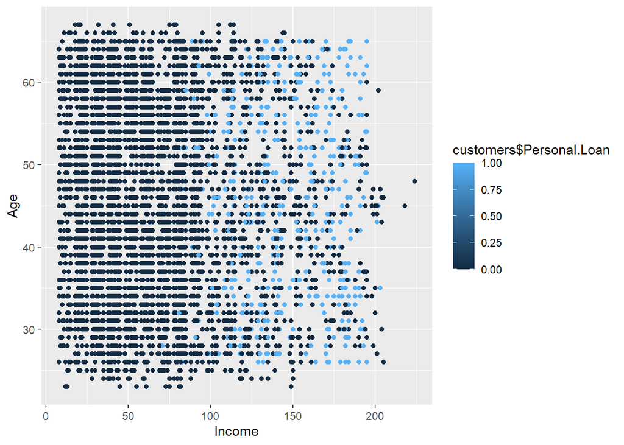

```r
ggplot(customers, aes(x=Income, y=Age, colour=customers$Personal.Loan)) + geom_point()
```

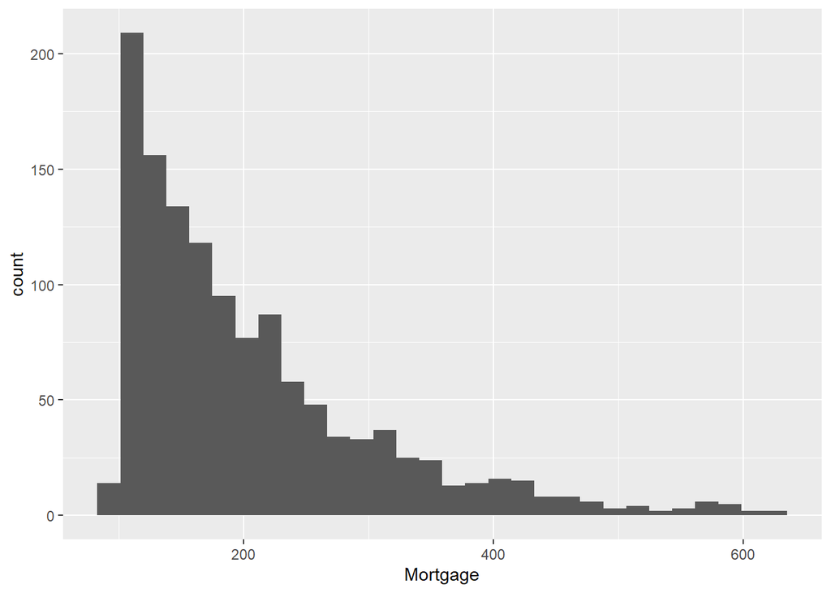

```r
UBm <- customers[customers$Mortgage>100,]
ggplot(UBm, aes(x= Mortgage)) + geom_histogram()
```

# Transformation and Subsetting

```r
uniban_cat <- c("Education", "Personal.Loan") #categorical Variables
uniban_num <- c("Age","Experience","Income","Family",
                "CCAvg","Mortgage","Securities.Account","CD.Account",
                "Online","CreditCard")        #numeric variables
cat_UB<-customers[which(colnames(customers) %in% uniban_cat)]
cat_UB<-data.frame(apply(cat_UB,2,as.character))
#Converting datatype for catagorical columns to factor
customers$Personal.Loan <- as.factor(customers$Personal.Loan)
customers$Education <- as.factor(customers$Education)
#Categorical variables to dummy variables conversion
dummy_UB <- fastDummies::dummy_columns(cat_UB %>% select(-Personal.Loan)) #Dummy variable for "Education" and "Personal.Loan"
dummy_UB <- dummy_UB %>% select(-Education) %>% mutate(Personal.Loan=customers$Personal.Loan)
#Numerical Variables
numeric_UB <- customers[(which(colnames(customers) %in% uniban_num))]
UB <- cbind(numeric_UB,dummy_UB)
```

Since the Education variable contains 3 unique values (1, 2 or 3), we have to transform it in dummy variable before normalizing data.

## Partitioning of the data

In order to teach the model how to classify new data, we need to split our dataset in 2 different sets, Training set (60%) and Validation set (40%).

```r
#Partitioning 60%-40%
set.seed(123)
sample1 = createDataPartition(UB$Income, p=0.60, list=FALSE)

train_df = UB[sample1, ]
valid_df = UB[-sample1, ]

#Verifying if the two sets are well balanced
summary(train_df$Income)
```

```
##    Min. 1st Qu.  Median    Mean 3rd Qu.    Max.
##     8.0    39.0    64.0    73.6    98.0   218.0
```

```r
summary(valid_df$Income)
```

```
##    Min. 1st Qu.  Median    Mean 3rd Qu.    Max.
##    8.00   39.00   64.00   74.03   98.00  224.00
```

# Normalization process

A k-NN model is very sensible to different scales of the variables, so in order to reduce the bias of certain variables on the prediction, we need to normalize the data. For this process, we use preProcess and predict functions from the Caret package. After the transformation phase, we know that the variable to be predicted (Personal_Loan) is the 14th and last variable of our dataset. Therefore, it is excluded from the process and it will be used as labels.

```r
#copy the training and validation sets
norm_train <- train_df
norm_valid <- valid_df

#normalizing data
norm_values <- preProcess(train_df[ , -14], method=c("center", "scale"))

#replacing original values with the normalized values
norm_train <- predict(norm_values, train_df[ , -14])
norm_valid <- predict(norm_values, valid_df[ , -14])
```

```r
#verifying min, median and max values of the normalized data
summary(norm_train)
```

```
##       Age             Experience           Income            Family
##  Min.   :-1.92510   Min.   :-1.99469   Min.   :-1.4351   Min.   :-1.2168
##  1st Qu.:-0.89106   1st Qu.:-0.87296   1st Qu.:-0.7569   1st Qu.:-1.2168
##  Median :-0.02936   Median :-0.01009   Median :-0.2100   Median :-0.3440
##  Mean   : 0.00000   Mean   : 0.00000   Mean   : 0.0000   Mean   : 0.0000
##  3rd Qu.: 0.83233   3rd Qu.: 0.85278   3rd Qu.: 0.5337   3rd Qu.: 0.5289
##  Max.   : 1.86637   Max.   : 1.97452   Max.   : 3.1589   Max.   : 1.4018
##      CCAvg            Mortgage       Securities.Account   CD.Account
##  Min.   :-1.1158   Min.   :-0.5467   Min.   :-0.3538    Min.   :-0.2606
##  1st Qu.:-0.7065   1st Qu.:-0.5467   1st Qu.:-0.3538    1st Qu.:-0.2606
##  Median :-0.2388   Median :-0.5467   Median :-0.3538    Median :-0.2606
##  Mean   : 0.0000   Mean   : 0.0000   Mean   : 0.0000    Mean   : 0.0000
##  3rd Qu.: 0.3458   3rd Qu.: 0.4572   3rd Qu.:-0.3538    3rd Qu.:-0.2606
##  Max.   : 4.7307   Max.   : 5.6629   Max.   : 2.8258    Max.   : 3.8357
##      Online          CreditCard       Education_1       Education_2
##  Min.   :-1.2363   Min.   :-0.6501   Min.   :-0.8279   Min.   :-0.632
##  1st Qu.:-1.2363   1st Qu.:-0.6501   1st Qu.:-0.8279   1st Qu.:-0.632
##  Median : 0.8086   Median :-0.6501   Median :-0.8279   Median :-0.632
##  Mean   : 0.0000   Mean   : 0.0000   Mean   : 0.0000   Mean   : 0.000
##  3rd Qu.: 0.8086   3rd Qu.: 1.5378   3rd Qu.: 1.2075   3rd Qu.: 1.582
##  Max.   : 0.8086   Max.   : 1.5378   Max.   : 1.2075   Max.   : 1.582
##   Education_3
##  Min.   :-0.6667
##  1st Qu.:-0.6667
##  Median :-0.6667
##  Mean   : 0.0000
##  3rd Qu.: 1.4994
##  Max.   : 1.4994
```

```r
summary(norm_valid)
```

```
##       Age               Experience            Income
##  Min.   :-1.9250998   Min.   :-1.994693   Min.   :-1.435093
##  1st Qu.:-0.8695198   1st Qu.:-0.872960   1st Qu.:-0.756937
##  Median :-0.0293643   Median :-0.010089   Median :-0.210037
##  Mean   :-0.0005117   Mean   :-0.002661   Mean   : 0.009467
##  3rd Qu.: 0.8323336   3rd Qu.: 0.766495   3rd Qu.: 0.533747
##  Max.   : 1.7802013   Max.   : 1.888228   Max.   : 3.290123
##      Family              CCAvg            Mortgage        Securities.Account
##  Min.   :-1.216844   Min.   :-1.1158   Min.   :-0.54668   Min.   :-0.35376
##  1st Qu.:-1.216844   1st Qu.:-0.7065   1st Qu.:-0.54668   1st Qu.:-0.35376
##  Median :-0.343973   Median :-0.2096   Median :-0.54668   Median :-0.35376
##  Mean   : 0.005088   Mean   : 0.0431   Mean   : 0.05488   Mean   :-0.05458
##  3rd Qu.: 0.528898   3rd Qu.: 0.4043   3rd Qu.: 0.48992   3rd Qu.:-0.35376
##  Max.   : 1.401770   Max.   : 4.7307   Max.   : 5.84403   Max.   : 2.82584
##    CD.Account           Online          CreditCard        Education_1
##  Min.   :-0.26062   Min.   :-1.2363   Min.   :-0.65008   Min.   :-0.82785
##  1st Qu.:-0.26062   1st Qu.:-1.2363   1st Qu.:-0.65008   1st Qu.:-0.82785
##  Median :-0.26062   Median : 0.8086   Median :-0.65008   Median :-0.82785
##  Mean   :-0.03305   Mean   :-0.0399   Mean   :-0.01717   Mean   : 0.06352
##  3rd Qu.:-0.26062   3rd Qu.: 0.8086   3rd Qu.: 1.53775   3rd Qu.: 1.20754
##  Max.   : 3.83567   Max.   : 0.8086   Max.   : 1.53775   Max.   : 1.20754
##   Education_2        Education_3
##  Min.   :-0.63198   Min.   :-0.66672
##  1st Qu.:-0.63198   1st Qu.:-0.66672
##  Median :-0.63198   Median :-0.66672
##  Mean   :-0.02701   Mean   :-0.04117
##  3rd Qu.: 1.58180   3rd Qu.: 1.49939
##  Max.   : 1.58180   Max.   : 1.49939
```

```r
dim(norm_train)
```

```
## [1] 3002   13
```

```r
dim(norm_valid)
```

```
## [1] 1998   13
```

Our Training and Validation sets are composed by, respectively, 3,002 rows and 13 columns, and 1,998 rows and 13 columns.

# Tranining

Data is now ready to be using in the creation of the k-NN model. First, we add a new customer of Universal Bank with the following characteristics:

```r
new_cust <- data.frame(
  "Age" = 40,
  "Experience" = 10,
  "Income" = 84,
  "Family" = 2,
  "CCAvg" = 2,
  "Mortgage" = 0,
  "Securities.Account" = 0,
  "CD.Account" = 0,
  "Online" = 1,
  "CreditCard" = 1,
  "Education_1" = 0,
  "Education_2" = 1,
  "Education_3" = 0)
head(new_cust)
```

```
##   Age Experience Income Family CCAvg Mortgage Securities.Account CD.Account
## 1  40         10     84      2     2        0                  0          0
##   Online CreditCard Education_1 Education_2 Education_3
## 1      1          1           0           1           0
```

Our predictors are given by the normalized training set. We use Personal Loan variable from the original training set. The k-NN model is run now with k=1.

```r
#k-NN Model with k=1
set.seed(1234)
predicted_labels1 <- knn(norm_train,
                         new_cust,
                         cl=train_df$Personal.Loan, k=1)
predicted_labels1
```

```
## [1] 0
## attr(,"nn.index")
##      [,1]
## [1,] 2108
## attr(,"nn.dist")
##          [,1]
## [1,] 90.61017
## Levels: 0
```

```r
head(predicted_labels1)
```

```
## [1] 0
## Levels: 0
```

```r
summary(predicted_labels1)
```

```
## 0
## 1
```

According to the 1-NN classifier, the new customer would not accept an offer for a Personal Loan.

Now, we want to test the model for different values of k and find the one that perform best.

```r
#Testing for different values of k
accuracy_df <- data.frame(k = seq(1,20,1), accuracy = rep(0,20))
for(i in 1:20){
  knn_pred <- knn(norm_train, norm_valid, cl = train_df$Personal.Loan, k=i)
  accuracy_df[i,2] <- confusionMatrix(knn_pred, valid_df$Personal.Loan)$overall[1]
}
accuracy_df
```

```
##     k  accuracy
## 1   1 0.9599600
## 2   2 0.9569570
## 3   3 0.9604605
## 4   4 0.9559560
## 5   5 0.9574575
## 6   6 0.9529530
## 7   7 0.9559560
## 8   8 0.9529530
## 9   9 0.9539540
## 10 10 0.9509510
## 11 11 0.9494494
## 12 12 0.9469469
## 13 13 0.9504505
## 14 14 0.9469469
## 15 15 0.9479479
## 16 16 0.9459459
## 17 17 0.9489489
## 18 18 0.9454454
## 19 19 0.9469469
## 20 20 0.9449449
```

```r
max(accuracy_df[c("accuracy")])
```

```
## [1] 0.9604605
```

```r
#Running k-NN with k=3
best_pred_labels <- knn(norm_train,
                        norm_valid,
                        cl= train_df$Personal.Loan,
                        k=3, prob = TRUE)
```

# Confusion Matrix using the best K

The Confusion Matrix gives an outlook of how well the model performed, showing both the predicted labels and the validation labels. Moreover, we can look at the different measures of performance, such as Accuracy, Sensitivity, Precision, and Specificity.

```r
#Confusion Matrix
CM_valid_labels <- valid_df$Personal.Loan
CM_pred_labels <- best_pred_labels
CrossTable(x=CM_valid_labels, y=CM_pred_labels,prop.chisq = TRUE)
```

```
##
##
##    Cell Contents
## |-------------------------|
## |                       N |
## | Chi-square contribution |
## |           N / Row Total |
## |           N / Col Total |
## |         N / Table Total |
## |-------------------------|
##
##
## Total Observations in Table:  1998
##
##
##                 | CM_pred_labels
## CM_valid_labels |         0 |         1 | Row Total |
## ----------------|-----------|-----------|-----------|
##               0 |      1804 |        13 |      1817 |
##                 |     6.287 |    91.856 |           |
##                 |     0.993 |     0.007 |     0.909 |
##                 |     0.965 |     0.102 |           |
##                 |     0.903 |     0.007 |           |
## ----------------|-----------|-----------|-----------|
##               1 |        66 |       115 |       181 |
##                 |    63.118 |   922.115 |           |
##                 |     0.365 |     0.635 |     0.091 |
##                 |     0.035 |     0.898 |           |
##                 |     0.033 |     0.058 |           |
## ----------------|-----------|-----------|-----------|
##    Column Total |      1870 |       128 |      1998 |
##                 |     0.936 |     0.064 |           |
## ----------------|-----------|-----------|-----------|
##
##
```

The model wrongly predicted 79 outcomes. From the Matrix we see the model’s performance: - Accuracy = 96.04% - Sensitivity = 63.54% - Precision = 89.84% - Specificity = 99.28%